# Reproducible Research

## Course Project 1

### Loading and preprocessing the data

For the first part of the analysis, we need to load the data from the csv files and load the libraries we’ll need with the following:

```r
library(dplyr)
library(lubridate)
```

```r
library(ggplot2)

df<-read.csv("activity.csv")
```

Then validate that the data is correct

```r
head(df)
```

```
##   steps       date interval
## 1    NA 2012-10-01        0
## 2    NA 2012-10-01        5
## 3    NA 2012-10-01       10
## 4    NA 2012-10-01       15
## 5    NA 2012-10-01       20
## 6    NA 2012-10-01       25
```

After that, proceed to adjust the class of the variables and we create a variable for the weekday of the date:

```r
df$date<-ymd(df$date)

df<- df %>% mutate(weekday=weekdays(df$date))

head(df)
```

```
##   steps       date interval weekday
## 1    NA 2012-10-01        0  Monday
## 2    NA 2012-10-01        5  Monday
## 3    NA 2012-10-01       10  Monday
## 4    NA 2012-10-01       15  Monday
## 5    NA 2012-10-01       20  Monday
## 6    NA 2012-10-01       25  Monday
```

### What is mean total number of steps taken per day?

Then we proceed to group by date and sum all the steps taken by day, and the histogram, excluding the values “NA”

```r
sum.day<-df %>% group_by(date) %>%summarise(steps=sum(steps,na.rm = TRUE))
sum.day
```

```
## # A tibble: 61 x 2
##    date       steps
##    <date>     <int>
##  1 2012-10-01     0
##  2 2012-10-02   126
##  3 2012-10-03 11352
##  4 2012-10-04 12116
##  5 2012-10-05 13294
##  6 2012-10-06 15420
##  7 2012-10-07 11015
##  8 2012-10-08     0
##  9 2012-10-09 12811
## 10 2012-10-10  9900
## # ... with 51 more rows
```

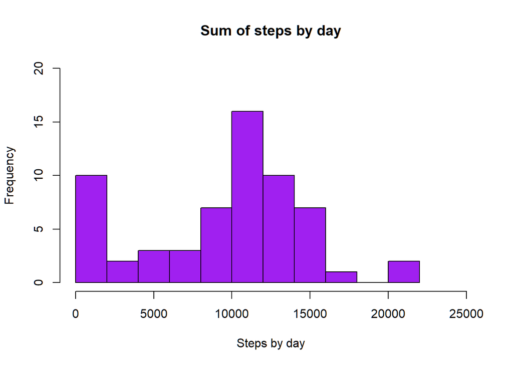

```r
hist(sum.day$steps, breaks = 10,xlim = c(0,25000), ylim=c(0,20), main="Sum of steps by day", xlab = "Steps by day", col="purple")
```

```r
mean.day<-round(mean(sum.day$steps),digits = 2)

median.day<-median(sum.day$steps)
```

- The mean number of steps per day is **9354.23**
- The median number of steps per day is **10395**

### What is the average daily activity pattern?

For this question we group by interval and calculate the mean of every interval and proceed to plot:

```r
mean.interval<-df %>% group_by(interval) %>%summarise(steps=mean(steps,na.rm = TRUE))
```

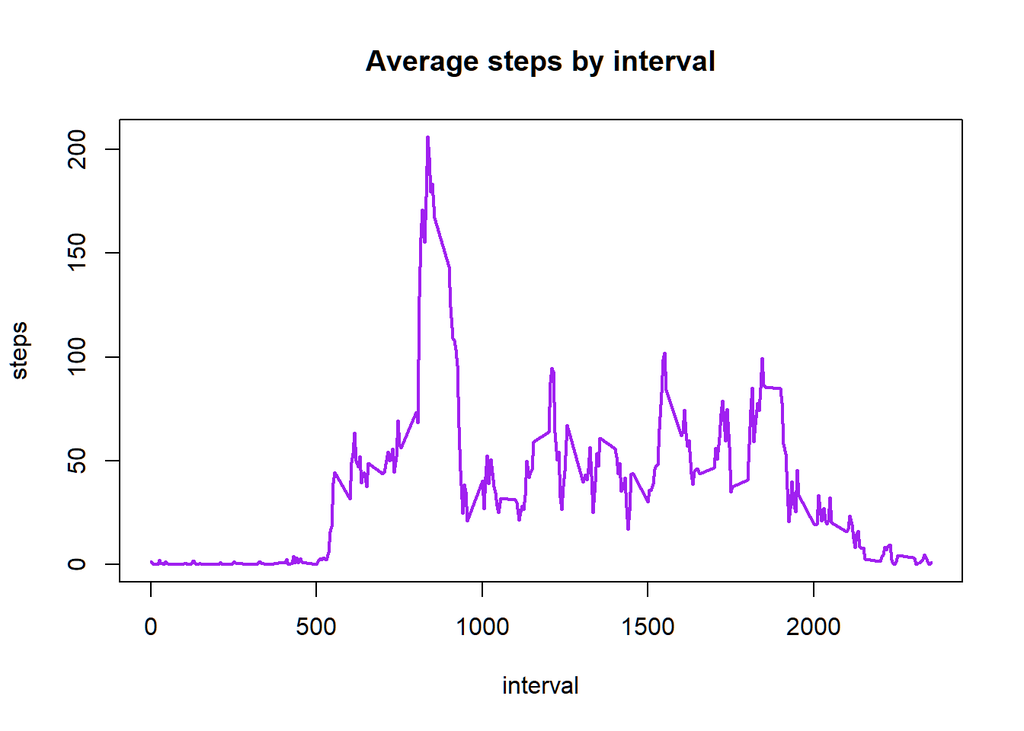

```r
max.interval<-mean.interval[which.max(mean.interval$steps),]$interval
with(mean.interval,plot(interval,steps,main="Average steps by interval", type="l", col="purple" , lwd=2))
```

Then Interval where the maximum number of steps occurs is at 835

### Imputing missing values

```r
na.df<-sum(is.na(df$steps))
```

The number of values NA of the data is **2304**

For this process the values of NA in the step data with the mean of steps for the specific interval. After the substitution were made, a new histogram is made to show the difference with the previous one

```r
df2<-df
df2$steps[is.na(df2$steps)]<-mean.interval$steps[match(df2$interval[is.na(df2$steps)],mean.interval$interval)]
sum.day2<-df2 %>% group_by(date) %>%summarise(steps=sum(steps,na.rm = TRUE))
```

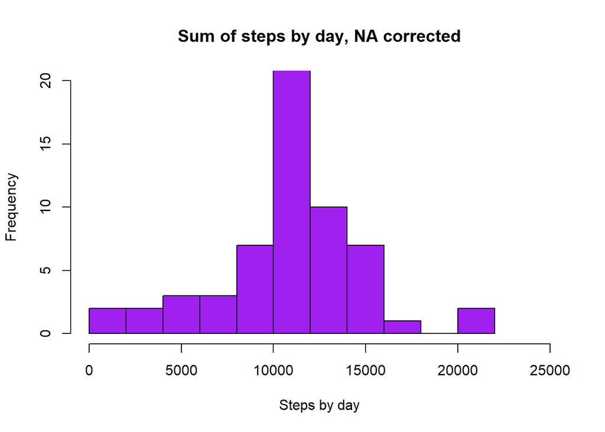

```r
hist(sum.day2$steps, breaks = 10,xlim = c(0,25000), ylim=c(0,20), main="Sum of steps by day, NA corrected", xlab = "Steps by day", col="purple")
```

```r
mean.day2<-mean(sum.day2$steps)
median.day2<-median(sum.day2$steps)
```

### Are there differences in activity patterns between weekdays and weekends?

A new variable is added to the dataframe and a plot to evidence de differences of steps between weekends and weekdays is shown

```r
df<-df %>% mutate(type.wd=ifelse(weekday=="Saturday"| weekday=="Sunday","Weekend","Weekday"))
mean.interval2<-df %>% group_by(type.wd,interval) %>%summarise(steps=mean(steps,na.rm = TRUE))
```

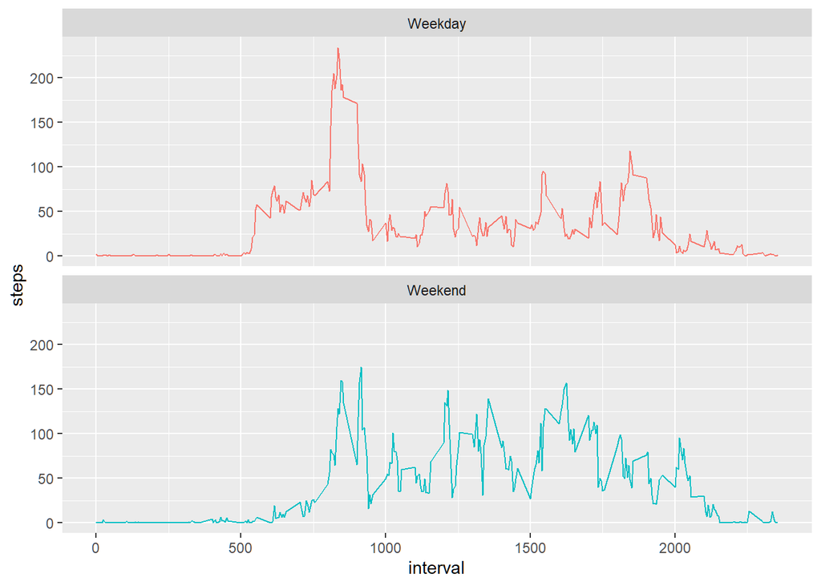

```r
ggplot(mean.interval2,aes(interval,steps,col=type.wd))+ geom_line()+facet_wrap(~type.wd,nrow = 2,ncol = 1)+theme(legend.position = "none")
```